# Tree Based Methods and Ensemble Learning

Phoebe Tan

2023-08-26

**1. Tree based methods**

Partitions the feature space into a set of rectangles, followed by fitting a simple model in each of them

-Regression tree

-Classification tree

**2. Ensemble learning**

Ensemble learning is a technique where multiple models are combined to solve a problem, typically with the goal of improving the predictive performance compared to using individual models alone.

-Bagging (random forest): Reduces variance of an estimated prediction function by fitting the same prediction function many times to bootstrapped sampled versions of the training data and averages the result. Helpful when model is complex and easy to overfit.

-Boosting (ada boosting): Iiteratively improves the performance of a model by giving more weight to misclassified instances in each iteration.

## Preprocessing Data

```r
#Data Link: https://www.kaggle.com/datasets/rajyellow46/wine-quality
data= read.csv("winequalityN.csv")
str(data)
```

```
## 'data.frame':    6497 obs. of  13 variables:
##  $ type                : chr  "white" "white" "white" "white" ...
##  $ fixed.acidity       : num  7 6.3 8.1 7.2 7.2 8.1 6.2 7 6.3 8.1 ...
##  $ volatile.acidity    : num  0.27 0.3 0.28 0.23 0.23 0.28 0.32 0.27 0.3 0.22 ...
##  $ citric.acid         : num  0.36 0.34 0.4 0.32 0.32 0.4 0.16 0.36 0.34 0.43 ...
##  $ residual.sugar      : num  20.7 1.6 6.9 8.5 8.5 6.9 7 20.7 1.6 1.5 ...
##  $ chlorides           : num  0.045 0.049 0.05 0.058 0.058 0.05 0.045 0.045 0.049 0.044 ...
##  $ free.sulfur.dioxide : num  45 14 30 47 47 30 30 45 14 28 ...
##  $ total.sulfur.dioxide: num  170 132 97 186 186 97 136 170 132 129 ...
##  $ density             : num  1.001 0.994 0.995 0.996 0.996 ...
##  $ pH                  : num  3 3.3 3.26 3.19 3.19 3.26 3.18 3 3.3 3.22 ...
##  $ sulphates           : num  0.45 0.49 0.44 0.4 0.4 0.44 0.47 0.45 0.49 0.45 ...
##  $ alcohol             : num  8.8 9.5 10.1 9.9 9.9 10.1 9.6 8.8 9.5 11 ...
##  $ quality             : int  6 6 6 6 6 6 6 6 6 6 ...
```

```r
head(data)
```

```
##    type fixed.acidity volatile.acidity citric.acid residual.sugar chlorides
## 1 white           7.0             0.27        0.36           20.7     0.045
## 2 white           6.3             0.30        0.34            1.6     0.049
## 3 white           8.1             0.28        0.40            6.9     0.050
## 4 white           7.2             0.23        0.32            8.5     0.058
## 5 white           7.2             0.23        0.32            8.5     0.058
## 6 white           8.1             0.28        0.40            6.9     0.050
##   free.sulfur.dioxide total.sulfur.dioxide density   pH sulphates alcohol
## 1                  45                  170  1.0010 3.00      0.45     8.8
## 2                  14                  132  0.9940 3.30      0.49     9.5
## 3                  30                   97  0.9951 3.26      0.44    10.1
## 4                  47                  186  0.9956 3.19      0.40     9.9
## 5                  47                  186  0.9956 3.19      0.40     9.9
## 6                  30                   97  0.9951 3.26      0.44    10.1
##   quality
## 1       6
## 2       6
## 3       6
## 4       6
## 5       6
## 6       6
```

```r
sum(is.na(data))
```

```
## [1] 38
```

```r
#There are NA values
data= na.omit(data)
#Remove leverage values
# Calculate the leverage values for each observation
leverage <- hatvalues(lm(alcohol ~ density, data = data))
# Identify the observations with high leverage values
high_leverage <- which(leverage > (2 * mean(leverage)))

# Exclude the high leverage observations from your analysis
data <- data[-high_leverage, ]
str(data)
```

```
## 'data.frame':    6087 obs. of  13 variables:
##  $ type                : chr  "white" "white" "white" "white" ...
##  $ fixed.acidity       : num  6.3 8.1 7.2 7.2 8.1 6.2 6.3 8.1 8.1 8.6 ...
##  $ volatile.acidity    : num  0.3 0.28 0.23 0.23 0.28 0.32 0.3 0.22 0.27 0.23 ...
##  $ citric.acid         : num  0.34 0.4 0.32 0.32 0.4 0.16 0.34 0.43 0.41 0.4 ...
##  $ residual.sugar      : num  1.6 6.9 8.5 8.5 6.9 7 1.6 1.5 1.45 4.2 ...
##  $ chlorides           : num  0.049 0.05 0.058 0.058 0.05 0.045 0.049 0.044 0.033 0.035 ...
##  $ free.sulfur.dioxide : num  14 30 47 47 30 30 14 28 11 17 ...
##  $ total.sulfur.dioxide: num  132 97 186 186 97 136 132 129 63 109 ...
##  $ density             : num  0.994 0.995 0.996 0.996 0.995 ...
##  $ pH                  : num  3.3 3.26 3.19 3.19 3.26 3.18 3.3 3.22 2.99 3.14 ...
##  $ sulphates           : num  0.49 0.44 0.4 0.4 0.44 0.47 0.49 0.45 0.56 0.53 ...
##  $ alcohol             : num  9.5 10.1 9.9 9.9 10.1 9.6 9.5 11 12 9.7 ...
##  $ quality             : int  6 6 6 6 6 6 6 6 5 5 ...
##  - attr(*, "na.action")= 'omit' Named int [1:34] 18 34 55 87 99 140 175 225 250 268 ...
##   ..- attr(*, "names")= chr [1:34] "18" "34" "55" "87" ...
```

```r
head(data)
```

```
##    type fixed.acidity volatile.acidity citric.acid residual.sugar chlorides
## 2 white           6.3             0.30        0.34            1.6     0.049
## 3 white           8.1             0.28        0.40            6.9     0.050
## 4 white           7.2             0.23        0.32            8.5     0.058
## 5 white           7.2             0.23        0.32            8.5     0.058
## 6 white           8.1             0.28        0.40            6.9     0.050
## 7 white           6.2             0.32        0.16            7.0     0.045
##   free.sulfur.dioxide total.sulfur.dioxide density   pH sulphates alcohol
## 2                  14                  132  0.9940 3.30      0.49     9.5
## 3                  30                   97  0.9951 3.26      0.44    10.1
## 4                  47                  186  0.9956 3.19      0.40     9.9
## 5                  47                  186  0.9956 3.19      0.40     9.9
## 6                  30                   97  0.9951 3.26      0.44    10.1
## 7                  30                  136  0.9949 3.18      0.47     9.6
##   quality
## 2       6
## 3       6
## 4       6
## 5       6
## 6       6
## 7       6
```

```r
data$quality=as.factor(data$quality)
str(data)
```

```
## 'data.frame':    6087 obs. of  13 variables:
##  $ type                : chr  "white" "white" "white" "white" ...
##  $ fixed.acidity       : num  6.3 8.1 7.2 7.2 8.1 6.2 6.3 8.1 8.1 8.6 ...
##  $ volatile.acidity    : num  0.3 0.28 0.23 0.23 0.28 0.32 0.3 0.22 0.27 0.23 ...
##  $ citric.acid         : num  0.34 0.4 0.32 0.32 0.4 0.16 0.34 0.43 0.41 0.4 ...
##  $ residual.sugar      : num  1.6 6.9 8.5 8.5 6.9 7 1.6 1.5 1.45 4.2 ...
##  $ chlorides           : num  0.049 0.05 0.058 0.058 0.05 0.045 0.049 0.044 0.033 0.035 ...
##  $ free.sulfur.dioxide : num  14 30 47 47 30 30 14 28 11 17 ...
##  $ total.sulfur.dioxide: num  132 97 186 186 97 136 132 129 63 109 ...
##  $ density             : num  0.994 0.995 0.996 0.996 0.995 ...
##  $ pH                  : num  3.3 3.26 3.19 3.19 3.26 3.18 3.3 3.22 2.99 3.14 ...
##  $ sulphates           : num  0.49 0.44 0.4 0.4 0.44 0.47 0.49 0.45 0.56 0.53 ...
##  $ alcohol             : num  9.5 10.1 9.9 9.9 10.1 9.6 9.5 11 12 9.7 ...
##  $ quality             : Factor w/ 7 levels "3","4","5","6",..: 4 4 4 4 4 4 4 4 3 3 ...
##  - attr(*, "na.action")= 'omit' Named int [1:34] 18 34 55 87 99 140 175 225 250 268 ...
##   ..- attr(*, "names")= chr [1:34] "18" "34" "55" "87" ...
```

# 1) Conduct the regression tree and discuss the results + Random Forest

## Regression Tree

#Step 1: splitting data into a training set and a testing set.

```r
set.seed(1)
selected <- sample(1:dim(data)[1], size=round(dim(data)[1]*0.7))  #splitting the data into Train and test dataset
round(dim(data)[1]*0.7)
```

```
## [1] 4261
```

```r
train <- data[selected,]   # 70% t which means Randomly select 280 observations for Traning set
test <- data[-selected,]   # 30% which means Randomly select 120 observations for Traning set
train<- train[,9:12]
test<-test[,9:12]
```

#Step 2: Load the necessary packages.

```r
# Install packages "rpart", "rpart.plot" first, then load them into R
#install.packages('rpart')
library(rpart)
#install.packages('rpart.plot')
library(rpart.plot)
```

#Step 3: Build the initial regression tree. -First, we’ll build a large initial regression tree. We can ensure that the tree is large by using a small value for cp,

```r
set.seed(10)
#Fitting the model
fittree <- rpart(pH~., data=train, method="anova", cp=10^(-5))
# Display the CP table
printcp(fittree)
```

```
##
## Regression tree:
## rpart(formula = pH ~ ., data = train, method = "anova", cp = 10^(-5))
##
## Variables actually used in tree construction:
## [1] alcohol   density   sulphates
##
## Root node error: 110.97/4261 = 0.026043
##
## n= 4261
##
##             CP nsplit rel error  xerror     xstd
## 1   6.6002e-02      0   1.00000 1.00018 0.023447
## 2   2.4479e-02      1   0.93400 0.93471 0.021940
## 3   1.9304e-02      2   0.90952 0.91041 0.021680
```

[output cut: 236 more lines]

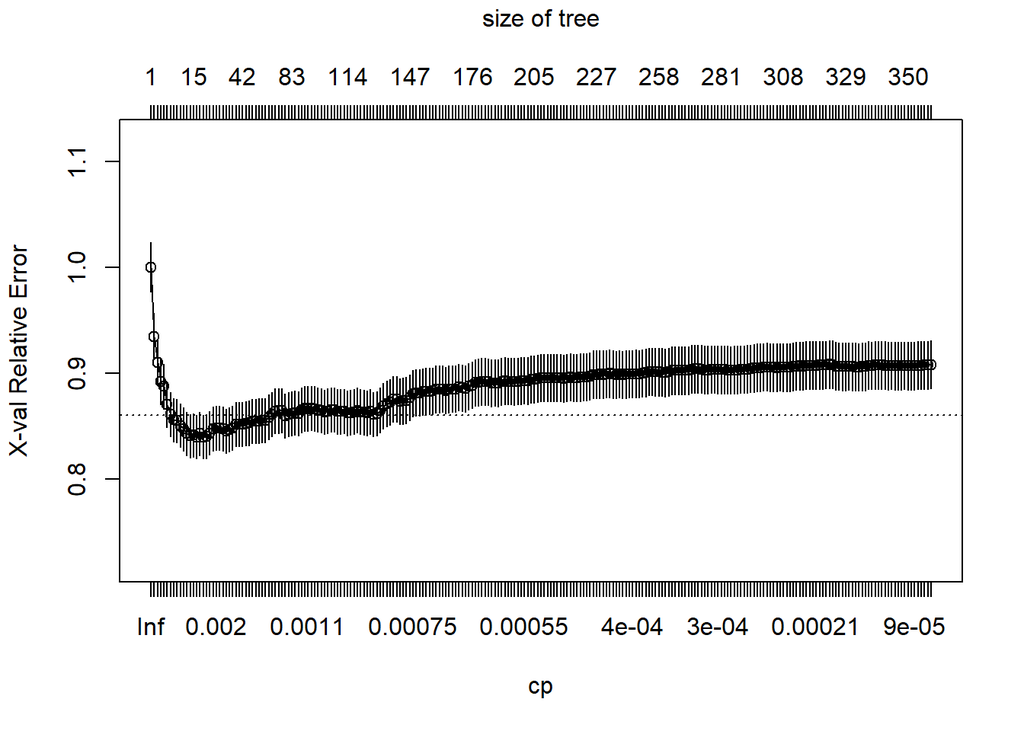

```r
# Visualize cross-validation results((xerror))
plotcp(fittree)
```

```r
bestcp <- fittree$cptable[which.min(fittree$cptable[,"xerror"]),"CP"]
bestcp
```

```
## [1] 0.002369457
```

In the plot above, we see that the CV error decreases sharply as cp value increases. This means that the size of the tree has been penalised more. After reaching a minimum point, CV error increases as cp value increases further. This means that penalizaing the size of the tree after the minimum cp value does not further reduce the CV error. Thus, based on the results above, the best cp value chosen in reference to the lowest Relative Error (at the minimum point) produced was = 0.002369457

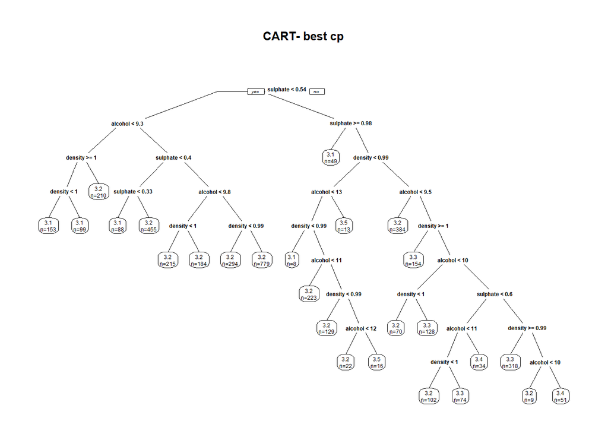

```r
#identify best cp value to use
bestcp <- fittree$cptable[which.min(fittree$cptable[,"xerror"]),"CP"]
fittreebest <- prune(fittree, cp=bestcp)
# Plot tree using package rpart.plot
prp(fittreebest, faclen=-3, extra=1, main="CART- best cp")
```

The regression tree is used to predict the pH value of each wine sample based on the variables density, sulphate and alcohol level.

Visualising the tree, the first split occurs where sulphate < 0.54. If Yes, we traverse down the left edge of and arrive at the second decision split where alcohol <9.3. If no, the decision split is at sulphate>=0.98. We do this repeatedly as we traverse down the tree.

```r
fittreebest$frame
```

```
##            var    n   wt         dev     yval   complexity ncompete nsurrogate
## 1    sulphates 4261 4261 110.9672613 3.220469 0.0660019677        2          2
## 2      alcohol 2477 2477  54.9587243 3.185285 0.0244791563        2          1
## 4      density  462  462   8.0975647 3.116126 0.0047419574        2          2
## 8      density  252  252   4.0984746 3.085317 0.0038592828        2          1
## 16      <leaf>  153  153   2.3143882 3.052157 0.0023694569        0          0
## 17      <leaf>   99   99   1.3558323 3.136566 0.0016703364        0          0
## 9       <leaf>  210  210   3.4728881 3.153095 0.0010827531        0          0
## 5    sulphates 2015 2015  44.1447747 3.201141 0.0193038417        2          1
## 10   sulphates  543  543   9.4746928 3.147459 0.0048912270        2          1
## 20      <leaf>   88   88   1.0493716 3.075568 0.0009695187        0          0
## 21      <leaf>  455  455   7.8825552 3.161363 0.0015617061        0          0
## 11     alcohol 1472 1472  32.5279874 3.220944 0.0049165328        2          1
## 22     density  399  399   8.0081434 3.189373 0.0032560561        2          1
## 44      <leaf>  215  215   3.3265935 3.161535 0.0011623867        0          0
```

[output cut: 37 more lines]

#Step 5: Use the tree to make predictions.

```r
predtreebest <- predict(fittreebest, test)

sqrt(sum((test$pH-predtreebest)^2))
```

```
## [1] 6.25641
```

## Random Forest For regression trees

```r
library(randomForest)
fittreer <- randomForest(pH~., data=train, importance=T, ntree=2000, mtry=4)
print(fittreer)
```

```
##
## Call:
##  randomForest(formula = pH ~ ., data = train, importance = T,      ntree = 2000, mtry = 4)
##                Type of random forest: regression
##                      Number of trees: 2000
## No. of variables tried at each split: 3
##
##           Mean of squared residuals: 0.0182899
##                     % Var explained: 29.77
```

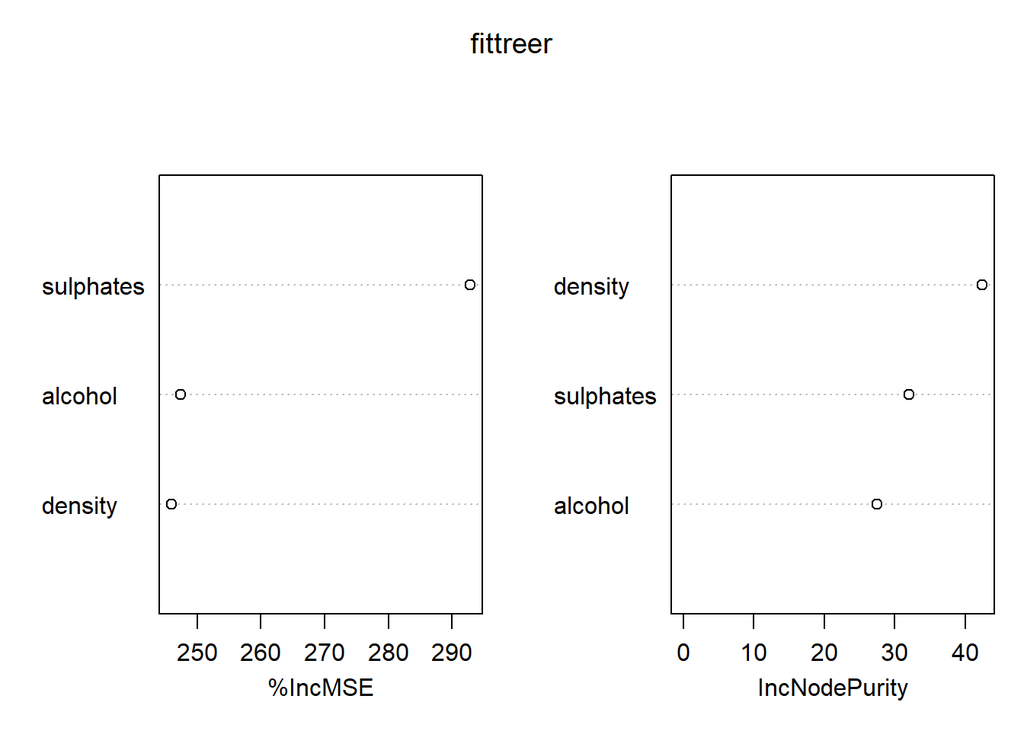

```r
# Look at what variables were important
varImpPlot(fittreer) #Variables with higher importance values are considered more important in predicting the response variable.
```

```r
importance(fittreer,scale=TRUE)
```

```
##            %IncMSE IncNodePurity
## density   245.9168      42.46337
## sulphates 292.8822      32.08055
## alcohol   247.4304      27.53046
```

%IncMSE is simply the average increase in squared residuals of the test set when variables are randomly permuted (little importance = little change in model when variable is removed or added) and IncNodePurity is the increase in homogeneity in the data partitions. Based on the values of %IncMSE, sulphates is the most important variable, followed by alcohol then lastly, density Based on IncNodePurity, the most important variable is density, sulphates then alcohol.

```r
#Predicting the variable using the test dataset
predtreer <- predict(fittreer, test)
# root mean square error (RMSE) of the prediction
sqrt(sum((test$pH-predtreer)^2))
```

```
## [1] 5.663358
```

Indeed, the random forest model’s RMSE(5.663358) is lower than that of a single regression tree (RMSE= 6.25641). This implies that Random forest produces a more accurate prediction than a single regression tree.

# 2. Conduct the classification tree and discuss the results + Random FOrest

#Step 1: splitting data into a training set and a testing set.

```r
set.seed(2)
selected <- sample(1:dim(data)[1], size=round(dim(data)[1]*0.7))  #splitting the data into Train and test dataset
round(dim(data)[1]*0.7)
```

```
## [1] 4261
```

```r
train <- data[selected,]   # 70% t which means Randomly select 280 observations for Traning set
test <- data[-selected,]   # 30% which means Randomly select 120 observations for Traning set
train<- train[,c(3,11,12,13)]
test<-test[,c(3,11,12,13)]
```

#Step 2: Build the initial classification tree.

```r
set.seed(1)
fittreec <- rpart(quality~., data=train, method="class", cp=10^(-5))
# Display the CP table
printcp(fittreec)
```

```
##
## Classification tree:
## rpart(formula = quality ~ ., data = train, method = "class",
##     cp = 10^(-5))
##
## Variables actually used in tree construction:
## [1] alcohol          sulphates        volatile.acidity
##
## Root node error: 2383/4261 = 0.55926
##
## n= 4261
##
##            CP nsplit rel error  xerror     xstd
## 1  0.10197230      0   1.00000 1.00000 0.013600
## 2  0.06252623      1   0.89803 0.89299 0.013696
## 3  0.00566513      2   0.83550 0.85061 0.013680
## 4  0.00503567      4   0.82417 0.84515 0.013676
## 5  0.00419639      6   0.81410 0.84599 0.013676
## 6  0.00272765      7   0.80990 0.84096 0.013672
## 7  0.00251783     10   0.80109 0.83298 0.013664
## 8  0.00209820     12   0.79606 0.83005 0.013661
## 9  0.00167856     15   0.78976 0.83298 0.013664
## 10 0.00125892     29   0.76374 0.84222 0.013673
## 11 0.00111904     44   0.74402 0.84515 0.013676
## 12 0.00104910     48   0.73940 0.84389 0.013675
## 13 0.00097916     54   0.73311 0.84389 0.013675
## 14 0.00093253     57   0.73017 0.84138 0.013672
## 15 0.00092321     71   0.71632 0.84599 0.013676
## 16 0.00083928     88   0.69744 0.84725 0.013677
## 17 0.00075535    130   0.65632 0.84893 0.013679
## 18 0.00069940    139   0.64876 0.84557 0.013676
## 19 0.00067142    142   0.64666 0.84767 0.013678
## 20 0.00062946    147   0.64331 0.85397 0.013682
## 21 0.00055952    161   0.63449 0.85480 0.013683
## 22 0.00052455    186   0.61729 0.85355 0.013682
## 23 0.00048958    191   0.61393 0.85355 0.013682
## 24 0.00041964    197   0.61099 0.85606 0.013684
## 25 0.00020982    229   0.59757 0.85984 0.013686
## 26 0.00001000    239   0.59547 0.86739 0.013690
```

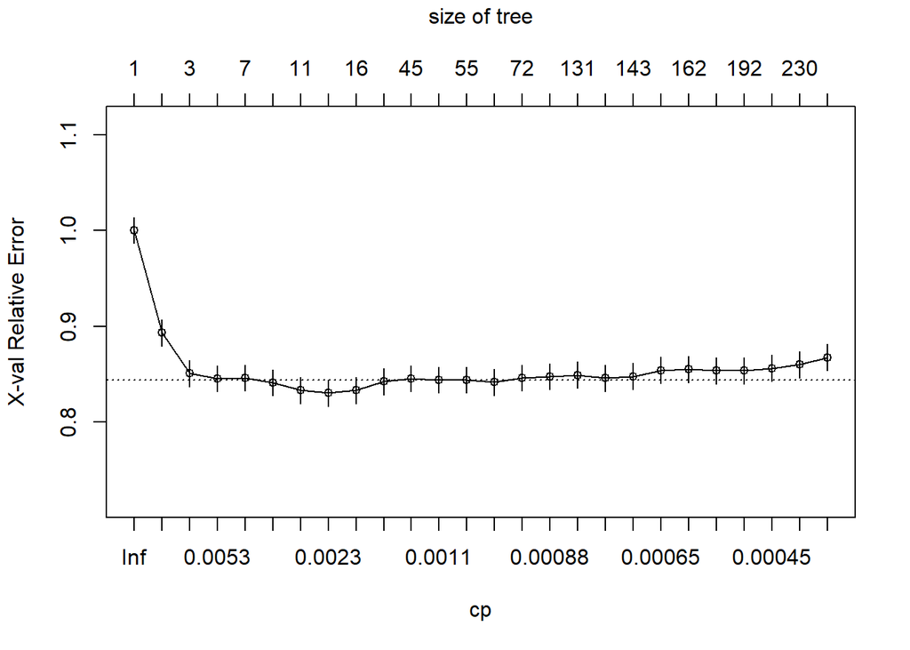

```r
# Visualize cross-validation results
plotcp(fittreec, cex=.8)
```

```r
cbestcp <- fittreec$cptable[which.min(fittreec$cptable[,"xerror"]),"CP"]
cbestcp
```

```
## [1] 0.002098196
```

In the plot above, we see that the CV error decreases sharply as cp value increases. This means that the size of the tree has been penalised more. After reaching a minimum point, CV error increases gradually as cp value increases further. This means that penalizaing the size of the tree after the minimum cp value does not further reduce the CV error. Thus, based on the results above, the best cp value chosen in reference to the lowest Relative Error (at the minimum point) produced was = 0.002098196

#Step 3: Prune the tree.

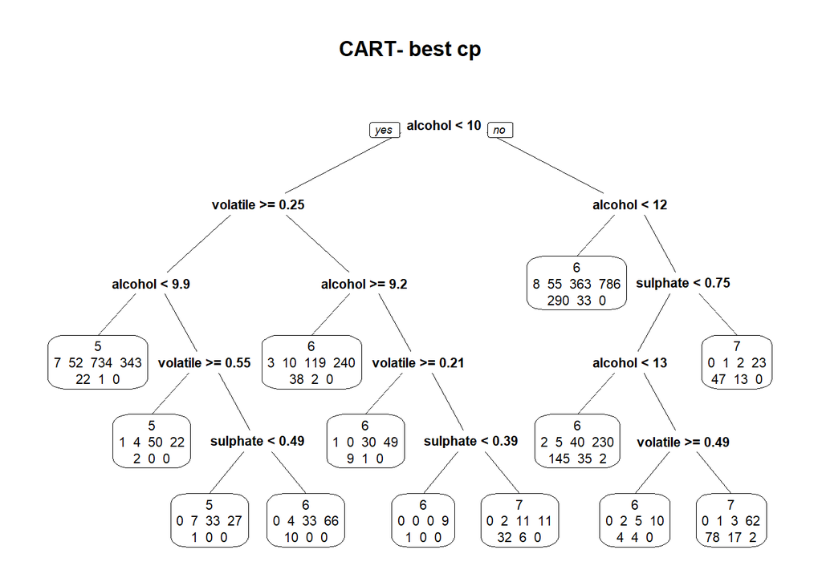

```r
# Prune the tree using the best cp (i.e., the cp with the smallest cross-validation error (xerror))
cbestcp <- fittreec$cptable[which.min(fittreec$cptable[,"xerror"]),"CP"]
fittreecbest <- prune(fittreec, cp=cbestcp)
# Plot tree using package rpart.plot
prp(fittreecbest, faclen=-3, extra=1, main="CART- best cp")
```

Visualizing the tree, the first split occurs where alcohol < 10 If Yes, we traverse down the left edge of and arrive at the second decision split where volatile>=0.25. If no, the decision split is at alcohol<12. We do this repeatedly as we traverse down the tree. With a new sample, we can predict its outcome by traversing down the tree with the input values. The predicted quality level of the wine sample is reflected as the top number of the leaf node. For eg, at the leftmost leaf node, the predicted quality level is 5.

#Step 4: Use the tree to make predictions.

```r
predtreec <- predict(fittreecbest, test)
predtreec_Class <- apply(predtreec, 1, function(one_row) return(colnames(predtreec)[which(one_row == max(one_row))]))
#Confusion table
table(test$quality)
```

```
##
##   3   4   5   6   7   8   9
##   6  65 609 793 299  53   1
```

```r
confusion=table(test$quality, predtreec_Class);confusion
```

```
##    predtreec_Class
##       5   6   7
##   3   1   4   1
##   4  30  35   0
##   5 358 245   6
##   6 163 588  42
##   7   9 238  52
##   8   1  39  13
##   9   0   1   0
```

```r
# root mean square error (RMSE) of the prediction
sum(diag(confusion))/sum(confusion)
```

```
## [1] 0.0230011
```